# Titanic

Thiago Pires

## Introduction

This article presents some analyzes with information about the passengers of the famous ship Titanic that tragically wrecked in 1912. The data was got in the platform [Kaggle](https://www.kaggle.com/c/titanic). In the figure below are showed the ports (with dates) and the place of shipwreck.

```r
require(dplyr)
require(leaflet)

ports <- bind_rows(
  tibble(codeloc = "C", location = "Cherbourg (10-04-1912)", long = -1.6109, lat = 49.6445),
  tibble(codeloc = "Q", location = "Queenstown (11-04-1912)", long = -8.3211, lat = 51.8535),
  tibble(codeloc = "S", location = "Southampton (10-04-1912)", long = -1.4191, lat = 50.7894)
)

ports %>%
  leaflet() %>%
  addTiles() %>%
  addCircleMarkers(~long, ~lat, popup = ~location, label = ~location) %>%
  addMarkers(lng = -49.9408, lat = 41.7258,
             icon = makeIcon("sinking-ship.jpg", 50, 50),
             label = "Naufrágio (14-04-1912)") %>%
  addCircleMarkers(lng = -73.9655, lat = 40.6832, popup = "New York", label = "New York", color = "green")
```

[interactive chart not shown]

## Read data

```r
require(magrittr)

train <- titanic::titanic_train
```

## Manipulation

```r
# tables and figures numbers

require(captioner)

fig_nums <- captioner(prefix = "Figure")
table_nums <- captioner(prefix = "Table")

# character to factor

train %<>%
  mutate(Survived = factor(x = Survived, labels = c("no", "yes")),
         Pclass = factor(x = Pclass, labels = c("1st", "2nd", "3rd")),
         Sex = factor(x = Sex))
```

## Univariate analysis

### Ticket class (Pclass)

There were more survivors in first class than in the second and third class (Figure 1).

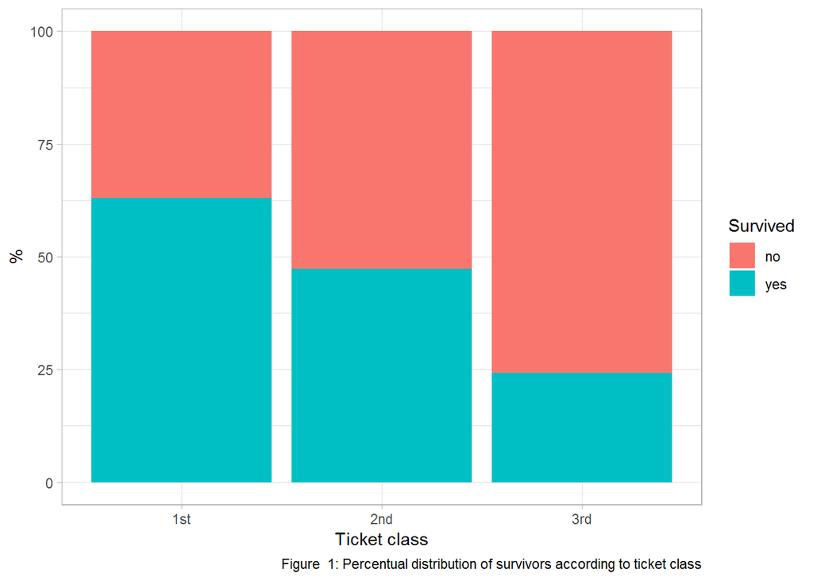

```r
require(ggplot2)

train %>% count(Pclass, Survived) %>%
  group_by(Pclass) %>%
  mutate(total = sum(n)) %>%
  ggplot(aes(Pclass, n * 100/total, fill = Survived)) + geom_col() +
  labs(x = "Ticket class", y = "%", fill = "Survived",
       caption = fig_nums("pclass", "Percentual distribution of survivors according to ticket class")) +
  theme_light()
```

The model shows the odds to survive in the third class is 81.18 (`1 - exp(-1.67039)`) percent lower than in the first class (Table 1).

```r
require(DT)

model <-
  glm(Survived ~ Pclass, family = binomial, data = train)

model %>%
  summary() %$% coefficients %>%
  datatable(caption = table_nums("pclass", "Model estimation"), options = list(dom = "t")) %>%
  formatRound(columns = 1:4 , digits = 3)
```

|  | Estimate | Std. Error | z value | Pr(>\|z\|) |
| --- | --- | --- | --- | --- |
| (Intercept) | 0.530628251062154 | 0.14090046045468 | 3.76597953867459 | 0.000165897378811786 |
| Pclass2nd | -0.639431110910952 | 0.204099169475062 | -3.13294322831177 | 0.00173062912555902 |
| Pclass3rd | -1.67039861222105 | 0.175910359447318 | -9.49573758742335 | 2.18657852855768e-21 |

### Sex

There were more female survivors than male (Figure 2).

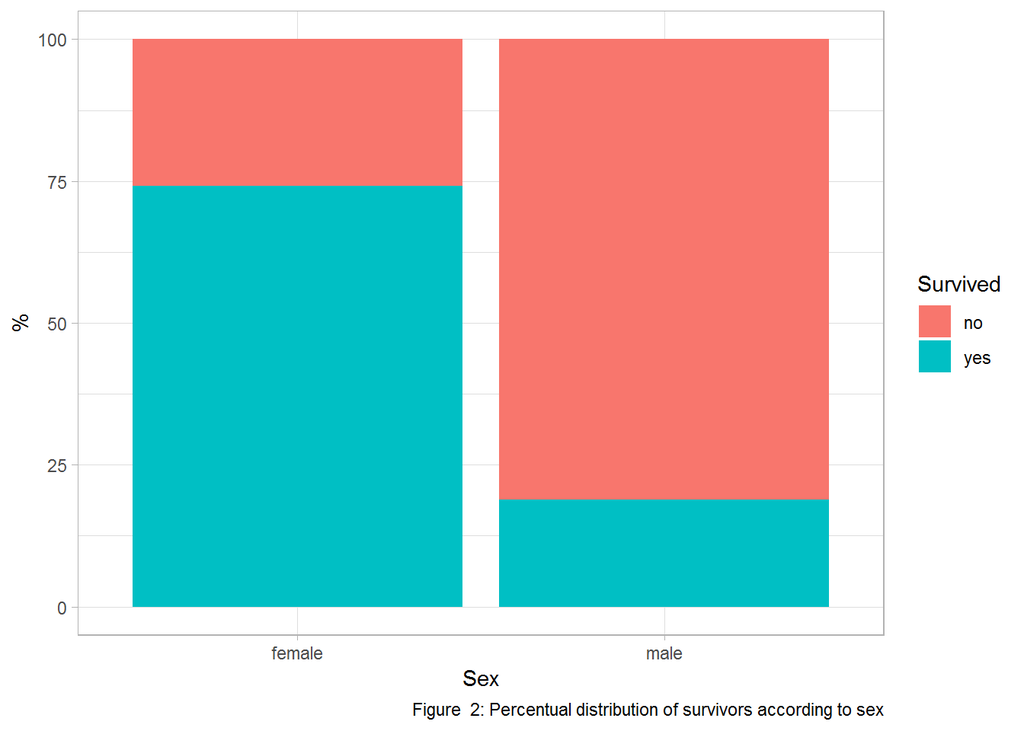

```r
train %>% count(Sex, Survived) %>%
  group_by(Sex) %>%
  mutate(total = sum(n)) %>%
  ggplot(aes(Sex, n * 100/total, fill = Survived)) + geom_col() +
  labs(x = "Sex", y = "%", fill = "Survived",
       caption = fig_nums("sex", "Percentual distribution of survivors according to sex")) +
  theme_light()
```

The model shows the odds to survive for male is 91.9 (`1 - exp(-2.513710)`) percent lower than for female (Table 2).

```r
model <-
  glm(Survived ~ Sex, family = binomial, data = train)

model %>%
  summary() %$% coefficients %>%
  datatable(caption = table_nums("sex", "Estimativas do modelo"), options = list(dom = "t")) %>%
  formatRound(columns = 1:4 , digits = 3)
```

|  | Estimate | Std. Error | z value | Pr(>\|z\|) |
| --- | --- | --- | --- | --- |
| (Intercept) | 1.05658929889019 | 0.128986418359451 | 8.1914771518483 | 2.58039408377701e-16 |
| Sexmale | -2.51370971257866 | 0.167178222189766 | -15.0361074525922 | 4.25866191254924e-51 |

## Interaction between Sex and Ticket Class

```r
model <-
  glm(Survived ~ Pclass*Sex, family = binomial, data = train)

model %>%
  summary() %$% coefficients %>%
  datatable(caption = table_nums("pclass_sex", "Model estimation"), options = list(dom = "t")) %>%
  formatRound(columns = 1:4 , digits = 3)
```

|  | Estimate | Std. Error | z value | Pr(>\|z\|) |
| --- | --- | --- | --- | --- |
| (Intercept) | 3.4122472178466 | 0.586789272686246 | 5.8151151983842 | 6.05921438792472e-09 |
| Pclass2nd | -0.955511445025277 | 0.724757912334851 | -1.31838704864503 | 0.187374114098644 |
| Pclass3rd | -3.41224721784658 | 0.609999531407549 | -5.59385219521883 | 2.22086037673752e-08 |
| Sexmale | -3.94939014992993 | 0.616060780888443 | -6.41071509897834 | 1.44838641872127e-10 |
| Pclass2nd:Sexmale | -0.184991785351983 | 0.793911712410127 | -0.233013044725581 | 0.815751276323458 |
| Pclass3rd:Sexmale | 2.0957552769838 | 0.657205137384577 | 3.18889058798917 | 0.00142819922449822 |

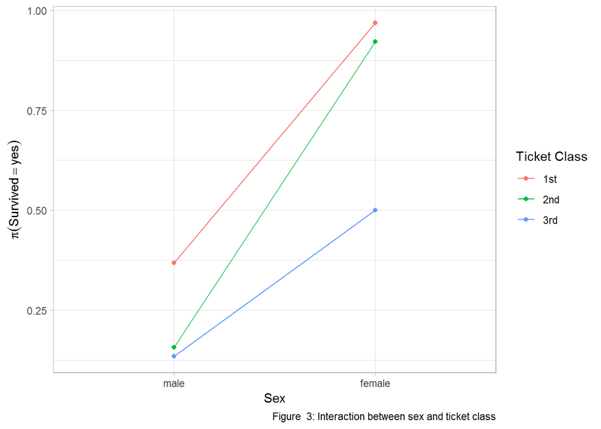

```r
# table with all possibilities

newdata <-
  expand.grid(Pclass = c("1st", "2nd", "3rd"),
              Sex = c("male", "female")) %>% as_tibble()

# predictions (probability)

newdata %<>%
  mutate(Pihat = model %>% predict(newdata = newdata, type = "response"))

newdata %>%
  ggplot(aes(Sex, Pihat, group = Pclass, colour = Pclass)) + geom_line() + geom_point() +
  labs(x = "Sex", y = expression(pi(Survived == yes)), colour = "Ticket Class",
       caption = fig_nums("pclass_sex", "Interaction between sex and ticket class")) +
  theme_light()
```

### Age

There is no difference between the distribution of age according to survived status (Figure 4).

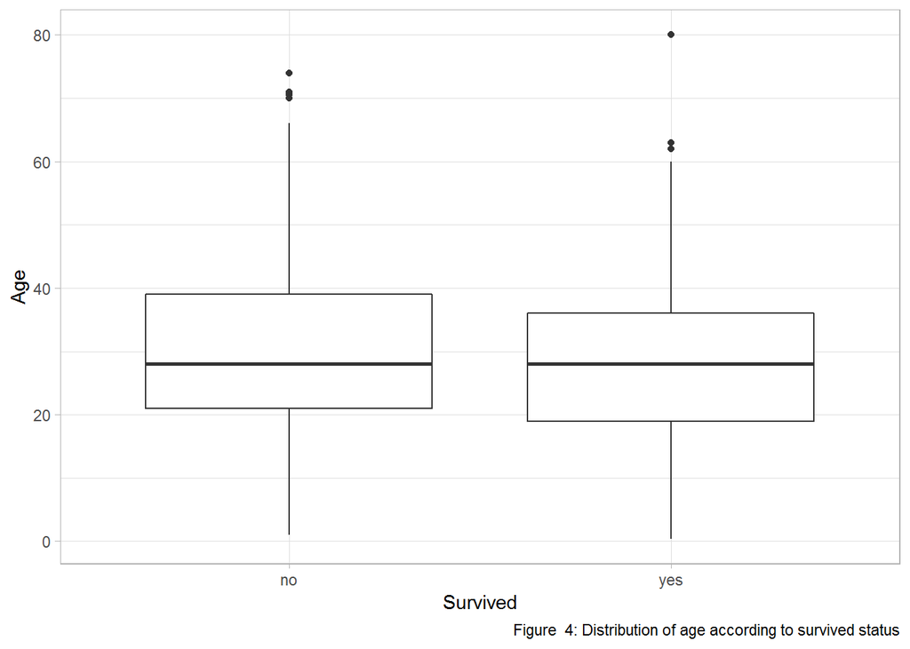

```r
train %>%
  ggplot(aes(Survived, Age)) + geom_boxplot() +
  labs(caption = fig_nums("age", "Distribution of age according to survived status")) +
  theme_light()
```

Fitting a simple model is showed a little age effect on survival probability (Table 4). The increase of one year in age decreases the odds of survival by 1.09 (`1 - exp(-0.0109635)`) percent.

```r
model <-
  glm(Survived ~ Age, family = binomial, data = train)

model %>%
  summary() %$% coefficients %>%
  datatable(caption = table_nums("age", "Model estimation"), options = list(dom = "t")) %>%
  formatRound(columns = 1:4 , digits = 3)
```

|  | Estimate | Std. Error | z value | Pr(>\|z\|) |
| --- | --- | --- | --- | --- |
| (Intercept) | -0.0567236402852363 | 0.173580433430398 | -0.326785912238093 | 0.74382981538089 |
| Age | -0.0109634529041344 | 0.00532994034260233 | -2.05695602566192 | 0.0396904560105911 |

## Interaction between Age and Ticket Class

Below, note that there is no interaction between age and ticket class (p-values > .05)

```r
model <-
  glm(Survived ~ Pclass*Age, family = binomial, data = train)

model %>%
  summary() %$% coefficients %>%
  datatable(caption = table_nums("pclass_age", "Model estimation"), options = list(dom = "t")) %>%
  formatRound(columns = 1:4 , digits = 3)
```

|  | Estimate | Std. Error | z value | Pr(>\|z\|) |
| --- | --- | --- | --- | --- |
| (Intercept) | 2.24251699722464 | 0.491280739183477 | 4.5646344714262 | 5.00365391275501e-06 |
| Pclass2nd | -1.05325202325154 | 0.632598859165351 | -1.664960358356 | 0.0959206648865786 |
| Pclass3rd | -2.40716090033604 | 0.564887214636685 | -4.26131241416792 | 2.03229898312564e-05 |
| Age | -0.0404383942198702 | 0.0114339017600958 | -3.53670995853749 | 0.000405144328849877 |
| Pclass2nd:Age | -0.00236032089681165 | 0.0168729060748189 | -0.139888225913507 | 0.888748304173883 |
| Pclass3rd:Age | -0.00172003795981675 | 0.0160495787048318 | -0.107170287236195 | 0.914653886993773 |